# SetFit Few Shot Classifier

This notebook documents the second proposed solution for automatically annotating the YouTube comments dataset. The solution of this notebook is based on SetFit [0], which utilizes large language models under the paradigm of few-shot learning. Contrary to the previous GPT3-based zero-shot learning approach, this approach requires labeled training examples. Still, SetFit can learn from considerably fewer training examples than many other approaches that utilize language models. While the authors of SetFit claim that SetFit is fast to train, the code in this notebook was run with GPU on BWUniCluster 2.0 in order to train the models within a reasonable amount of time.

## Import Libraries

```python
import pandas as pd
import numpy as np
from datasets import load_dataset, Dataset
from setfit import SetFitModel, Trainer, TrainingArguments, sample_dataset
from sklearn.metrics import accuracy_score, f1_score, confusion_matrix, ConfusionMatrixDisplay
import matplotlib.pyplot as plt
```

## Load Data

Just like in the previous notebook, the datasets are loaded and cleaned.

```python
all_comments = pd.read_parquet("data/scored_comments.parquet.gzip")

gold_standard_comments = pd.read_csv("data/gold_standard.csv")
# add 200 to each row ID to match annotations
gold_standard_comments["rowid"] += 200
gold_standard_comments = gold_standard_comments.set_index("rowid")

gold_standard_annotations = pd.read_csv("data/gs_annotated.csv")
# fix inconsistent column labelling
gold_standard_annotations = gold_standard_annotations.rename(columns={"comment_id": "rowid"})
gold_standard_annotations = gold_standard_annotations.set_index("rowid")

train_set_ids = pd.read_csv("data/train_sample_rowids.csv")
train_set_ids = train_set_ids["rowid"]
train_set_ids = train_set_ids.sort_values()
```

```python
# ref_persona contains a 2
# replace that with a 1
gold_standard_annotations["ref_persona"] = gold_standard_annotations["ref_persona"].replace(2, 1)

# ambiguity contains two -1s
# replace them with  1s
gold_standard_annotations["ambiguity"] = gold_standard_annotations["ambiguity"].replace(-1, 1)

# evaluation contains several -1s
# replace them with 1s
gold_standard_annotations["evaluation"] = gold_standard_annotations["evaluation"].replace(-1, 1)
```

## Split Up Data Into Training and Testing Sets

Then the data is split up into a training and testing dataset.

```python
test_set_ids = pd.Series(np.setdiff1d(gold_standard_annotations.index, train_set_ids))

gold_standard_comments_train = gold_standard_comments.loc[train_set_ids]
gold_standard_comments_test = gold_standard_comments.loc[test_set_ids]

gold_standard_annotations_train = gold_standard_annotations.loc[train_set_ids]
gold_standard_annotations_test = gold_standard_annotations.loc[test_set_ids]
```

```python
print(f"training set size: {len(gold_standard_annotations_train)}")
print(f"testing set size: {len(gold_standard_annotations_test)}")
```

```
training set size: 300
testing set size: 900
```

## Train SetFit Classifiers

The following function is used to train a SetFit model on predicting one attribute at a time. To finally obtain a full dataset containing annotations for all attributes, multiple models are trained and then used to annotate the unlabeled dataset.

SetFit uses pre-trained sentence transformer models and fine-tunes them with contrastive learning. Contrastive learning is a few-shot learning technique that increases the amount of training data by forming positive and negative pairs of training examples. A positive pair contains examples of the same class while a negative pair contains examples of different classes. The model is then fine-tuned to increase the similarity of embeddings of positive pairs and decrease the similarity of embeddings of negative pairs.

One important group of hyperparameters of the SetFit model is concerned with the sampling strategy that is used to generate positive and negative pairs. We chose to first reduce the training dataset size by sampling examples of all attribute and label combinations. The table below shows the value counts for all attributes in the training dataset.

```python
value_counts_train_set = pd.DataFrame(columns=gold_standard_annotations_train.columns[1:], index=[-1, 0, 1])
for col in gold_standard_annotations_train.columns[1:]:
    value_counts_col = gold_standard_annotations_train[col].value_counts()
    for idx, val in gold_standard_annotations_train[col].value_counts().items():
        value_counts_train_set.loc[idx, col] = val

value_counts_train_set
```

|  | excl_other | ref_persona | sentiment_overall | ambiguity | comprehension | memory_relate | self_relate | evaluation | future | sympathy_antipathy | empathy_counterempathy | emotion_release |
| --- | --- | --- | --- | --- | --- | --- | --- | --- | --- | --- | --- | --- |
| -1 | NaN | NaN | 6 | NaN | NaN | NaN | NaN | NaN | NaN | NaN | NaN | NaN |
| 0 | 277 | 77 | 94 | 205 | 211 | 243 | 216 | 108 | 194 | 146 | 229 | 231 |
| 1 | 23 | 222 | 151 | 46 | 40 | 8 | 35 | 143 | 56 | 105 | 21 | 20 |

It can be seen that there are plenty of examples for most attributes and values, but there are also attribute and value combinations with only a few examples (e.g. negative sentiment_overall and positive memory_relate value). We chose to sample 20 positive and negative examples, as this sample size is possible for most attribute and value combinations. In cases where there are fewer than 20 examples, the maximum amount is sampled

Another hyperparameter is num_iterations. This hyperparameter controls the number of positive and negative pairs that are constructed from each example. We set this parameter to 10. As we have 20 positive and negative examples for most attributes, this generates mostly unique pairs. Only in cases where the number of samples per attribute and value is below 10 this sampling strategy leads to duplicates. Assuming, a binary attribute with at least 10 positive and negative examples, the number of training pairs can be calculated as follows:

$(10\ positive\ samples + 10\ negative\ samples) \cdot 40\ unique\ examples = 800\ unique\ pairs$

After training a SetModel the function displays a short evalution on the test set.

```python
def train_and_evaluate_setfit_model(
    gold_standard_annotations_train,
    gold_standard_annotations_test,
    gold_standard_comments_train,
    gold_standard_comments_test,
    attribute
):
    """Function for training a setfit model and running a short evaluation"""

    # select attribute that the model learns to predict and join with comments
    train = gold_standard_annotations_train[[attribute]].join(gold_standard_comments_train[["comment"]])
    test = gold_standard_annotations_test[[attribute]].join(gold_standard_comments_test[["comment"]])
    train = train.dropna()
    test = test.dropna()
    # create huggingface datasets
    train_dataset = Dataset.from_pandas(train.reset_index(drop=True))
    test_dataset = Dataset.from_pandas(test.reset_index(drop=True))
    # sample train dataset
    train_dataset_sample = sample_dataset(train_dataset, label_column=attribute, num_samples=20)
    # number of classes
    n_classes = len(train[attribute].dropna().unique())

    # load pretrained model
    model = SetFitModel.from_pretrained("sentence-transformers/paraphrase-mpnet-base-v2")

    # train model
    args = TrainingArguments(
        batch_size=16,
        num_epochs=4,
        evaluation_strategy="epoch",
        save_strategy="epoch",
        sampling_strategy="num_iterations",
        num_iterations=10,
        load_best_model_at_end=True,
        seed=42
    )
    trainer = Trainer(
        model=model,
        args=args,
        train_dataset=train_dataset_sample,
        eval_dataset=test_dataset,
        metric="accuracy",
        column_mapping={"comment": "text", attribute: "label"}
    )
    trainer.train()

    # make predictions on the test dataset and evaluate model
    preds = model.predict(test_dataset["comment"])

    acc = accuracy_score(test_dataset[attribute], preds)
    f1 = f1_score(test_dataset[attribute], preds, average="binary" if n_classes == 2 else "micro")
    print(f"accuracy: {acc}\nf1-score: {f1}")

    cm = confusion_matrix(
        test_dataset[attribute],
        preds,
        labels=[0, 1] if n_classes == 2 else [-1, 0, 1]
    )
    cm_plot = ConfusionMatrixDisplay(cm, display_labels=[0, 1] if n_classes == 2 else [-1, 0, 1])
    cm_plot.plot()
    plt.show()

    return model
```

### Exclusion Criteria

The following models predict attributes of the exclusion criteria category.

#### Excl_other

The first SetFit model predicts the excl_other attribute.

```
***** Running training *****
  Num unique pairs = 800
  Batch size = 16
  Num epochs = 4
  Total optimization steps = 200
```

[200/200 05:43, Epoch 4/0]

| Epoch | Training Loss | Validation Loss | Rate |
| --- | --- | --- | --- |
| 1 | No log | 0.269600 | 0.000017 |
| 2 | No log | 0.339700 | 0.000011 |
| 3 | No log | 0.349400 | 0.000006 |
| 4 | No log | 0.349400 | 0.000000 |

```
Loading best SentenceTransformer model from step 50.
```

```
accuracy: 0.6877777777777778
f1-score: 0.1710914454277286
```

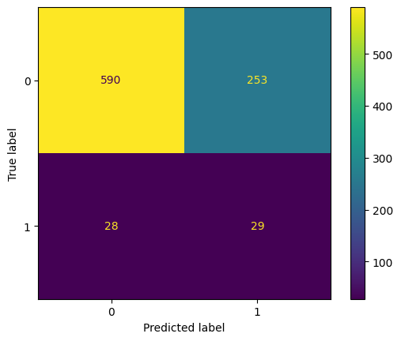

```python
excl_other_model = train_and_evaluate_setfit_model(
    gold_standard_annotations_train,
    gold_standard_annotations_test,
    gold_standard_comments_train,
    gold_standard_comments_test,
    "excl_other"
)
```

It can be seen that while the model mostly predicts the majority class, there are many cases where the model predicts the excl_other attribute to be true, where it actually is false. Besides that the validation loss increases after the first epoch of training.

#### Ref_persona

```
***** Running training *****
  Num unique pairs = 800
  Batch size = 16
  Num epochs = 4
  Total optimization steps = 200
```

[200/200 05:21, Epoch 4/0]

| Epoch | Training Loss | Validation Loss | Rate |
| --- | --- | --- | --- |
| 1 | No log | 0.240300 | 0.000017 |
| 2 | No log | 0.304900 | 0.000011 |
| 3 | No log | 0.303000 | 0.000006 |
| 4 | No log | 0.305400 | 0.000000 |

```
Loading best SentenceTransformer model from step 50.
```

```
accuracy: 0.7325842696629213
f1-score: 0.8143525741029642
```

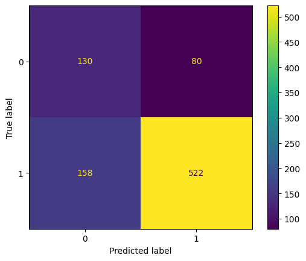

```python
ref_persona_model = train_and_evaluate_setfit_model(
    gold_standard_annotations_train,
    gold_standard_annotations_test,
    gold_standard_comments_train,
    gold_standard_comments_test,
    "ref_persona"
)
```

While the increase of validation loss is present for the ref_persona attribute, the predictions are more reliable.

### Sentiment

#### Sentiment_overall

```
***** Running training *****
  Num unique pairs = 920
  Batch size = 16
  Num epochs = 4
  Total optimization steps = 232
```

[232/232 05:12, Epoch 4/0]

| Epoch | Training Loss | Validation Loss | Rate |
| --- | --- | --- | --- |
| 1 | No log | 0.187100 | 0.000017 |
| 2 | No log | 0.195400 | 0.000011 |
| 3 | No log | 0.196400 | 0.000006 |
| 4 | No log | 0.199900 | 0.000000 |

```
Loading best SentenceTransformer model from step 58.
```

```
accuracy: 0.8013157894736842
f1-score: 0.8013157894736842
```

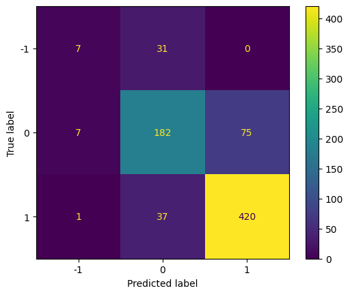

```python
sentiment_overall_model = train_and_evaluate_setfit_model(
    gold_standard_annotations_train,
    gold_standard_annotations_test,
    gold_standard_comments_train,
    gold_standard_comments_test,
    "sentiment_overall"
)
```

The model is able to predict a positive or neutral sentiment most of the time. Only comments with negative sentiment seem to be harder to predict for the model.

#### Ambiguity

```
***** Running training *****
  Num unique pairs = 800
  Batch size = 16
  Num epochs = 4
  Total optimization steps = 200
```

[200/200 05:03, Epoch 4/0]

| Epoch | Training Loss | Validation Loss | Rate |
| --- | --- | --- | --- |
| 1 | No log | 0.308300 | 0.000017 |
| 2 | No log | 0.353500 | 0.000011 |
| 3 | No log | 0.357600 | 0.000006 |
| 4 | No log | 0.357100 | 0.000000 |

```
Loading best SentenceTransformer model from step 50.
```

```
accuracy: 0.6552631578947369
f1-score: 0.3609756097560975
```

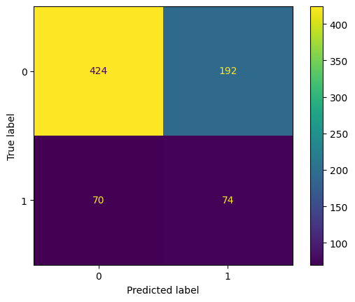

```python
ambiguity_model = train_and_evaluate_setfit_model(
    gold_standard_annotations_train,
    gold_standard_annotations_test,
    gold_standard_comments_train,
    gold_standard_comments_test,
    "ambiguity"
)
```

While the model correctly predicts the comments to be unambiguous most of the time, there are also many cases where comments are falsely predicted to be ambiguous.

### Cognitive Response

#### Comprehension

```
***** Running training *****
  Num unique pairs = 800
  Batch size = 16
  Num epochs = 4
  Total optimization steps = 200
```

[200/200 05:06, Epoch 4/0]

| Epoch | Training Loss | Validation Loss | Rate |
| --- | --- | --- | --- |
| 1 | No log | 0.287200 | 0.000017 |
| 2 | No log | 0.342200 | 0.000011 |
| 3 | No log | 0.347800 | 0.000006 |
| 4 | No log | 0.351500 | 0.000000 |

```
Loading best SentenceTransformer model from step 50.
```

```
accuracy: 0.5723684210526315
f1-score: 0.36647173489278756
```

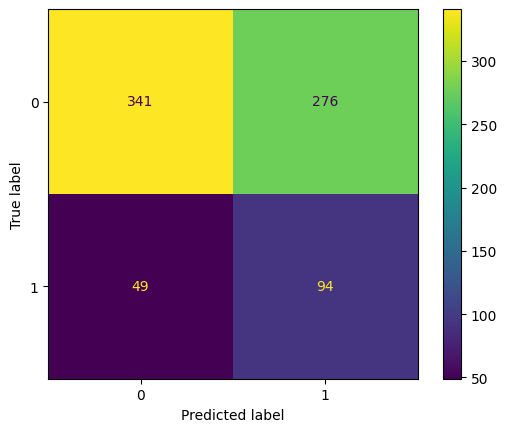

```python
comprehension_model = train_and_evaluate_setfit_model(
    gold_standard_annotations_train,
    gold_standard_annotations_test,
    gold_standard_comments_train,
    gold_standard_comments_test,
    "comprehension"
)
```

The prediction of the comprehension attribute does not seem to be very reliable with many false positives and negatives.

#### Memory_relate

```
***** Running training *****
  Num unique pairs = 560
  Batch size = 16
  Num epochs = 4
  Total optimization steps = 140
```

[140/140 06:24, Epoch 4/0]

| Epoch | Training Loss | Validation Loss | Rate |
| --- | --- | --- | --- |
| 1 | No log | 0.247500 | 0.000017 |
| 2 | No log | 0.305100 | 0.000011 |
| 3 | No log | 0.311100 | 0.000006 |
| 4 | No log | 0.314700 | 0.000000 |

```
Loading best SentenceTransformer model from step 35.
```

```
accuracy: 0.8881578947368421
f1-score: 0.17475728155339804
```

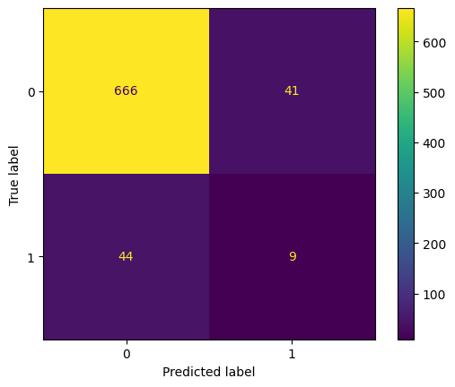

```python
memory_relate_model = train_and_evaluate_setfit_model(
    gold_standard_annotations_train,
    gold_standard_annotations_test,
    gold_standard_comments_train,
    gold_standard_comments_test,
    "memory_relate"
)
```

Considering the memory_relate attribute, the model makes correct predictions most of the time, most likely due to the fact that this attribute is highly imbalanced.

#### Self_relate

```
***** Running training *****
  Num unique pairs = 800
  Batch size = 16
  Num epochs = 4
  Total optimization steps = 200
```

[200/200 05:44, Epoch 4/0]

| Epoch | Training Loss | Validation Loss | Rate |
| --- | --- | --- | --- |
| 1 | No log | 0.271100 | 0.000017 |
| 2 | No log | 0.289600 | 0.000011 |
| 3 | No log | 0.293600 | 0.000006 |
| 4 | No log | 0.292900 | 0.000000 |

```
Loading best SentenceTransformer model from step 50.
```

```
accuracy: 0.6297760210803689
f1-score: 0.35103926096997695
```

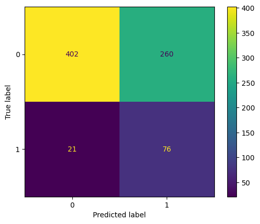

```python
self_relate_model = train_and_evaluate_setfit_model(
    gold_standard_annotations_train,
    gold_standard_annotations_test,
    gold_standard_comments_train,
    gold_standard_comments_test,
    "self_relate"
)
```

The predictions of the self_relate attribute are rather unsatisfactory with the model predicting the attribute to be present when it is not in a lot of comments.

#### Evaluation

```
***** Running training *****
  Num unique pairs = 800
  Batch size = 16
  Num epochs = 4
  Total optimization steps = 200
```

[200/200 04:49, Epoch 4/0]

| Epoch | Training Loss | Validation Loss | Rate |
| --- | --- | --- | --- |
| 1 | No log | 0.288000 | 0.000017 |
| 2 | No log | 0.330900 | 0.000011 |
| 3 | No log | 0.329100 | 0.000006 |
| 4 | No log | 0.333300 | 0.000000 |

```
Loading best SentenceTransformer model from step 50.
```

```
accuracy: 0.6526315789473685
f1-score: 0.6937354988399073
```

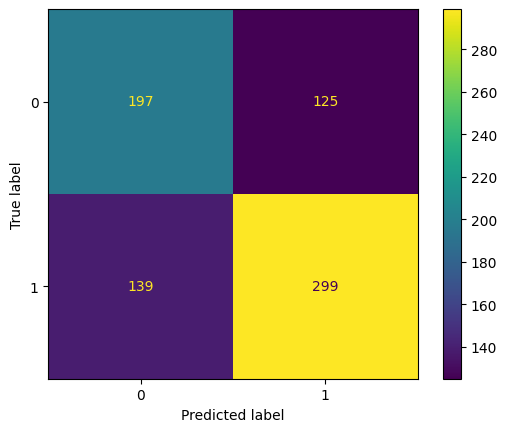

```python
evaluation_model = train_and_evaluate_setfit_model(
    gold_standard_annotations_train,
    gold_standard_annotations_test,
    gold_standard_comments_train,
    gold_standard_comments_test,
    "evaluation"
)
```

While the predictions for the evaluation attribute are not perfect either, the model seems to be able to correctly label this attribute in most cases.

#### Future

```
***** Running training *****
  Num unique pairs = 800
  Batch size = 16
  Num epochs = 4
  Total optimization steps = 200
```

[200/200 05:01, Epoch 4/0]

| Epoch | Training Loss | Validation Loss | Rate |
| --- | --- | --- | --- |
| 1 | No log | 0.275000 | 0.000017 |
| 2 | No log | 0.324100 | 0.000011 |
| 3 | No log | 0.331900 | 0.000006 |
| 4 | No log | 0.324700 | 0.000000 |

```
Loading best SentenceTransformer model from step 50.
```

```
accuracy: 0.7355263157894737
f1-score: 0.4937027707808564
```

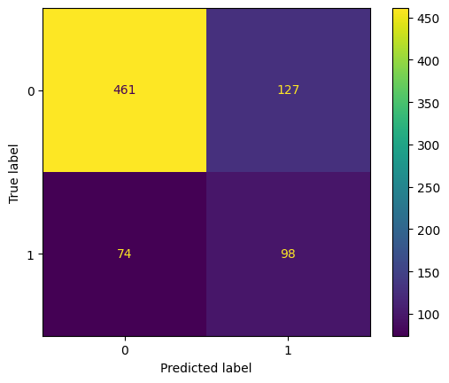

```python
future_model = train_and_evaluate_setfit_model(
    gold_standard_annotations_train,
    gold_standard_annotations_test,
    gold_standard_comments_train,
    gold_standard_comments_test,
    "future"
)
```

The predictions of the future attribute show a familiar pattern where the predictions are mostly correct for the majority class, but rather unreliable for the minority class. Still, the predictions are acceptable.

### Affective Response

#### Sympathy_antipathy

```
***** Running training *****
  Num unique pairs = 800
  Batch size = 16
  Num epochs = 4
  Total optimization steps = 200
```

[200/200 05:50, Epoch 4/0]

| Epoch | Training Loss | Validation Loss | Rate |
| --- | --- | --- | --- |
| 1 | No log | 0.269300 | 0.000017 |
| 2 | No log | 0.324600 | 0.000011 |
| 3 | No log | 0.326600 | 0.000006 |
| 4 | No log | 0.329100 | 0.000000 |

```
Loading best SentenceTransformer model from step 50.
```

```
accuracy: 0.6078947368421053
f1-score: 0.6037234042553191
```

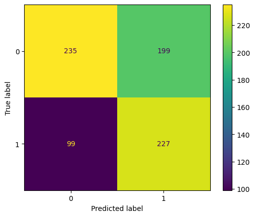

```python
sympathy_antipathy_model = train_and_evaluate_setfit_model(
    gold_standard_annotations_train,
    gold_standard_annotations_test,
    gold_standard_comments_train,
    gold_standard_comments_test,
    "sympathy_antipathy"
)
```

The predictions on the sympathy_antipathy attribute are rather unreliable and the model does not seem to be able to correctly annotate comments with this attribute.

#### Empathy_counterempathy

```
***** Running training *****
  Num unique pairs = 800
  Batch size = 16
  Num epochs = 4
  Total optimization steps = 200
```

[200/200 05:10, Epoch 4/0]

| Epoch | Training Loss | Validation Loss | Rate |
| --- | --- | --- | --- |
| 1 | No log | 0.297100 | 0.000017 |
| 2 | No log | 0.348200 | 0.000011 |
| 3 | No log | 0.361400 | 0.000006 |
| 4 | No log | 0.350300 | 0.000000 |

```
Loading best SentenceTransformer model from step 50.
```

```
accuracy: 0.5006587615283268
f1-score: 0.17067833698030635
```

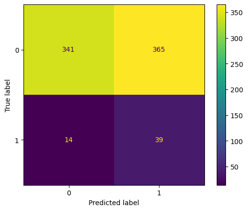

```python
empathy_counterempathy_model = train_and_evaluate_setfit_model(
    gold_standard_annotations_train,
    gold_standard_annotations_test,
    gold_standard_comments_train,
    gold_standard_comments_test,
    "empathy_counterempathy"
)
```

The predictions of the empathy_counterempathy attribute are very unreliable as well. The model predicts empathy or counterempathy to be present a lot of times, while it is actually only rarely present.

#### Emotion_release

```
***** Running training *****
  Num unique pairs = 800
  Batch size = 16
  Num epochs = 4
  Total optimization steps = 200
```

[200/200 05:42, Epoch 4/0]

| Epoch | Training Loss | Validation Loss | Rate |
| --- | --- | --- | --- |
| 1 | No log | 0.340600 | 0.000017 |
| 2 | No log | 0.358500 | 0.000011 |
| 3 | No log | 0.357500 | 0.000006 |
| 4 | No log | 0.355400 | 0.000000 |

```
Loading best SentenceTransformer model from step 50.
```

```
accuracy: 0.5197368421052632
f1-score: 0.17233560090702948
```

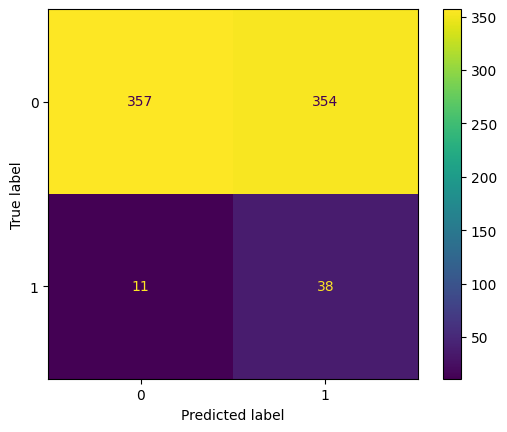

```python
emotion_release_model = train_and_evaluate_setfit_model(
    gold_standard_annotations_train,
    gold_standard_annotations_test,
    gold_standard_comments_train,
    gold_standard_comments_test,
    "emotion_release"
)
```

The predictions of the emotion_release attribute show the same pattern as the predictions of the empathy_counterempathy attribute where the attribute is positively labelled too many times.

## Conclusion

In comparison, the previous GPT-3-based approach showed more promising results, but due to the lack of reproducibility and the high cost the SetFit models are used to continue with the project and make predictions for the unlabelled dataset.

## Making Predictions

The same models are now used to make predictions for the unlabeled dataset. The predictions are then saved in a CSV file and analyzed in the next notebook.

```python
excl_other_preds = excl_other_model.predict(all_comments["comment"])
ref_persona_preds = ref_persona_model.predict(all_comments["comment"])
sentiment_overall_preds = sentiment_overall_model.predict(all_comments["comment"])
ambiguity_preds = ambiguity_model.predict(all_comments["comment"])
comprehension_preds = comprehension_model.predict(all_comments["comment"])
memory_relate_preds = memory_relate_model.predict(all_comments["comment"])
self_relate_preds = self_relate_model.predict(all_comments["comment"])
evaluation_preds = evaluation_model.predict(all_comments["comment"])
future_preds = future_model.predict(all_comments["comment"])
sympathy_antipathy_preds = sympathy_antipathy_model.predict(all_comments["comment"])
empathy_counterempathy_preds = empathy_counterempathy_model.predict(all_comments["comment"])
emotion_release_preds = emotion_release_model.predict(all_comments["comment"])
```

```python
predictions = pd.DataFrame({
    "comment_id": all_comments["comment_id"],
    "excl_other": excl_other_preds,
    "ref_persona": ref_persona_preds,
    "sentiment_overall": sentiment_overall_preds,
    "ambiguity": ambiguity_preds,
    "comprehension": comprehension_preds,
    "memory_relate": memory_relate_preds,
    "self_relate": self_relate_preds,
    "evaluation": evaluation_preds,
    "future": future_preds,
    "sympathy_antipathy": sympathy_antipathy_preds,
    "empathy_counterempathy": empathy_counterempathy_preds,
    "emotion_release": emotion_release_preds
})

predictions.to_csv("data/setfit_predictions.csv", index=False)
```

## References

[0] Tunstall et al. (2022). Efficient Few-Shot Learning Without Prompts. ArXiv.